# R Notebook

Here you’ll generate your own data to make sure you understand what PCA is doing

Generate 4 variables W, X, Y, and Z

X and Y should not be correlated

They are independent

```r
library(tidyverse)
```

[output not shown]

W and X should have a mild correlation ( < 0.5) Y and Z should have a mild correlation ( > 0.9)

```r
w = 2*x + noise
cor(x,w)
```

```
[1] 0.1466441
```

```r
y = rnorm(10, 6, 1)
error = rnorm(10, 6, 0.1)

z = y/2 + error
cor(y, z)
```

```
[1] 0.9786116
```

Here, it’s important to note that: The correction of two variables A and B is not determined by the linear regression 𝐵=0.4×𝑋 does not mean that the correlation cor(A,B) = 0.4 Correction is factor of the noise in the linear regressio. For example, for 𝐵=0.4×𝑋+𝜖 , the larger the noise component, the samller will be the correction between A and B

Generate a variable outcome as a linear combination of W, X, Y, and Z i.e., choose values for the coefficients 𝛽0 , 𝛽1 , etc.. and compute outcome 𝑜𝑢𝑡𝑐𝑜𝑚𝑒=𝛽0+𝛽1×𝑊+𝛽2×𝑋+𝛽3×𝑌+𝛽4×𝑍

```r
model_1 = lm(x~ y + w:z, data = my_table)
summary(model_1)
```

```
Call:
lm(formula = x ~ y + w:z, data = my_table)

Residuals:
    Min      1Q  Median      3Q     Max
-1.2244 -0.5442 -0.1823  0.5001  1.5553

Coefficients:
             Estimate Std. Error t value Pr(>|t|)
(Intercept)  3.108722   3.443020   0.903    0.397
y           -0.106552   0.487146  -0.219    0.833
w:z          0.003105   0.012312   0.252    0.808

Residual standard error: 0.9352 on 7 degrees of freedom
Multiple R-squared:  0.02535,   Adjusted R-squared:  -0.2531
F-statistic: 0.09104 on 2 and 7 DF,  p-value: 0.914
```

```r
outcome
```

```
 [1] 122.97505 114.50062 105.32682 120.28167 102.09872 118.52340 121.55739  96.70099 117.37580
[10] 117.40070
```

```r
model_4 = lm(outcome~., data = my_table)
summary(model_4)
```

[output not shown]

Model your outcome using W, X, Y, and Z. Do your results match your model params?

```r
model_2 = lm(w~z + y:z, data = my_table)
summary(model_2)
```

```
Call:
lm(formula = w ~ z + y:z, data = my_table)

Residuals:
    Min      1Q  Median      3Q     Max
-4.6124 -1.6715  0.8112  2.2277  2.5905

Coefficients:
            Estimate Std. Error t value Pr(>|t|)
(Intercept) 111.9379   112.0625   0.999    0.351
z           -14.5159    16.7107  -0.869    0.414
z:y           0.4460     0.7121   0.626    0.551

Residual standard error: 2.911 on 7 degrees of freedom
Multiple R-squared:  0.2943,    Adjusted R-squared:  0.09263
F-statistic: 1.459 on 2 and 7 DF,  p-value: 0.2953
```

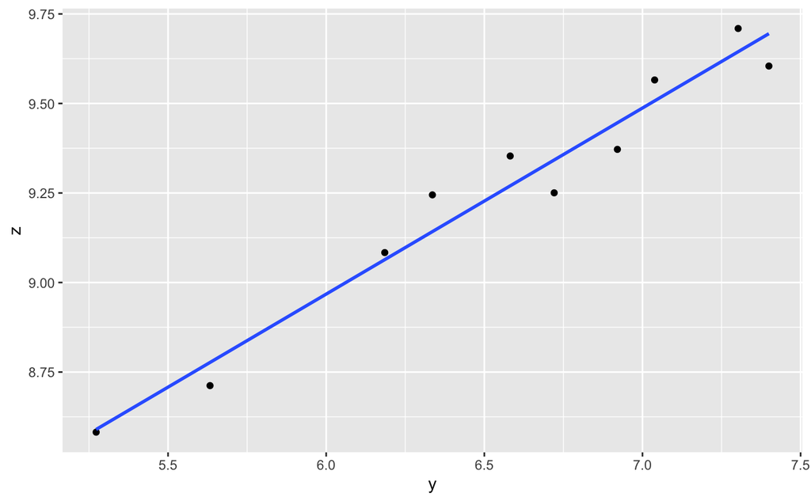

```r
ggplot(my_table, aes(y, z)) +
  geom_point() +
  geom_smooth(method=lm, se=FALSE)
```

```r
dif_error = rnorm(10, 0, 1)
output = 4*w + 3*x + 2*y + dif_error
attempt = lm(output ~ x + y + w + z)
summary(attempt)
```

```
Call:
lm(formula = output ~ x + y + w + z)

Residuals:
      1       2       3       4       5       6       7       8       9      10
 0.7132 -0.2438  1.6769  0.4823 -0.6018 -0.4833 -0.4910 -0.3640 -0.5636 -0.1247

Coefficients:
            Estimate Std. Error t value Pr(>|t|)
(Intercept)  41.6431    29.4151   1.416 0.216025
x             3.1334     0.4102   7.639 0.000612 ***
y             6.3274     2.4437   2.589 0.048882 *
w             4.1033     0.1300  31.571 5.99e-07 ***
z            -7.6624     4.7903  -1.600 0.170595
---
Signif. codes:  0 ‘***’ 0.001 ‘**’ 0.01 ‘*’ 0.05 ‘.’ 0.1 ‘ ’ 1

Residual standard error: 0.9915 on 5 degrees of freedom
Multiple R-squared:  0.9967,    Adjusted R-squared:  0.994
F-statistic: 372.8 on 4 and 5 DF,  p-value: 2.254e-06
```

Use PCA to reduce the dimensionality of your dataset Can you explain why you don’t need to include the outcome?

Use the bi-plot to visualize the contributions of your initial variables

```r
res_pca = prcomp(my_table, scale=TRUE)
summary(res_pca)
```

```
Importance of components:
                          PC1    PC2    PC3     PC4
Standard deviation     1.5393 0.9781 0.8096 0.13544
Proportion of Variance 0.5924 0.2392 0.1639 0.00459
Cumulative Proportion  0.5924 0.8316 0.9954 1.00000
```

```r
str(res_pca)
```

```
List of 5
 $ sdev    : num [1:4] 1.539 0.978 0.81 0.135
 $ rotation: num [1:4, 1:4] -0.4494 -0.1844 0.6107 0.6253 0.0188 ...
  ..- attr(*, "dimnames")=List of 2
  .. ..$ : chr [1:4] "w" "x" "y" "z"
  .. ..$ : chr [1:4] "PC1" "PC2" "PC3" "PC4"
 $ center  : Named num [1:4] 4.77 2.55 6.54 9.25
  ..- attr(*, "names")= chr [1:4] "w" "x" "y" "z"
 $ scale   : Named num [1:4] 3.056 0.835 0.695 0.369
  ..- attr(*, "names")= chr [1:4] "w" "x" "y" "z"
 $ x       : num [1:10, 1:4] -2.56 -0.737 0.672 1.351 -2.177 ...
  ..- attr(*, "dimnames")=List of 2
  .. ..$ : NULL
  .. ..$ : chr [1:4] "PC1" "PC2" "PC3" "PC4"
 - attr(*, "class")= chr "prcomp"
```

```r
res_pca$rotation
```

```
         PC1        PC2        PC3         PC4
w -0.4493859 0.01883633 -0.8916376 -0.05176850
x -0.1844352 0.97563638  0.1152450 -0.02891209
y  0.6107203 0.17658247 -0.3441880  0.69092251
z  0.6253452 0.12883121 -0.2706209 -0.72049302
```

```r
res_pca$sdev^2
```

```
[1] 2.36946618 0.95672953 0.65546126 0.01834303
```

```r
res_pca$sdev^2/sum(res_pca$sdev^2)
```

```
[1] 0.592366544 0.239182383 0.163865316 0.004585757
```

```r
res_pca$rotation[4,2]
```

```
[1] 0.1288312
```

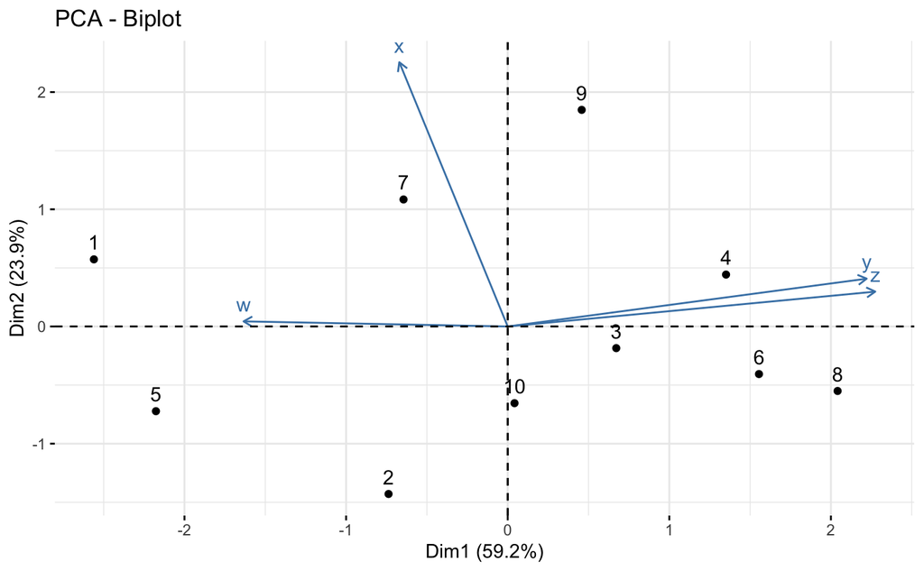

```r
fviz_pca_biplot(res_pca)
```

How efficient is the new lower-dimensional space representation at predicting the outcome? Do your results match your model params?